# 220111 RT results

## Packages

## Data File

Pre-processed data file (critical items only), outliers, fillers, practice, etc. removed. 6387 observations.

## Variable Prep

## Subsets

## RT - individual effects

The overall mean response time was 527.8 ms.

Auditorily masked speech was responded to more slowly than unmasked speech (540ms vs. 516ms; diff=24ms).

Visually masked speech was responded to more slowly than no visual obstructions (537ms vs. 519ms; diff=18ms).

**Audio diff becomes larger than Visual diff**

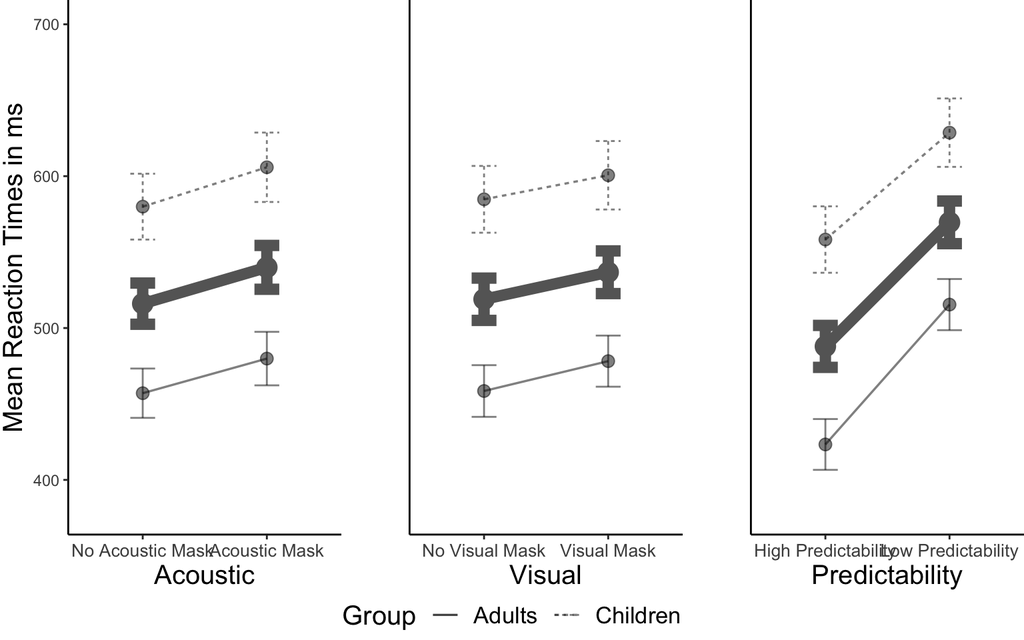

## RT - interaction

The individual acoustic or vidual effect is not big. But the interaction is strong.

Acoustic diff is 11ms there is no visual mask -> 40ms when there is visual mask.

Visual diff is 2ms there is no acoustic mask -> 31ms when there is acoustic mask.

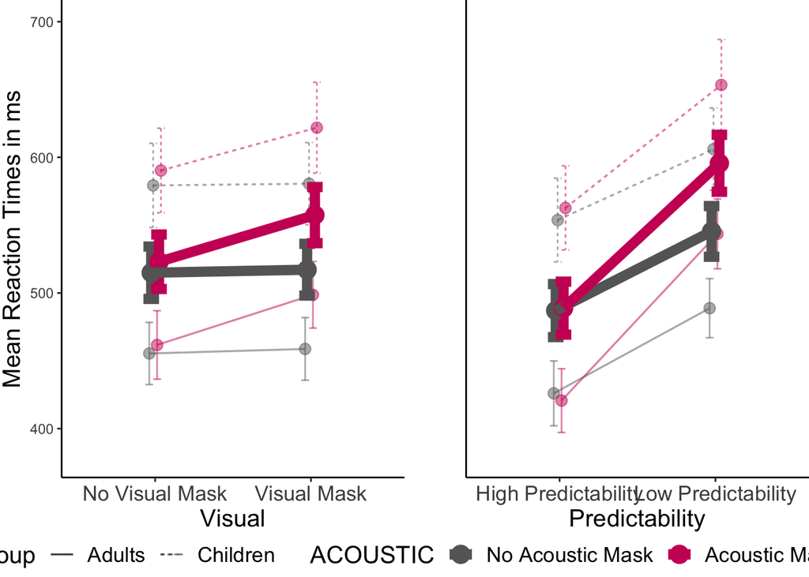

## Statistic model

6 interactions and 4 main effects (sum contrast coded) were included in the maximal model structure (see below).

The model was then optimized with the step function (checked against manual reduction).

If we run the same model, we get similar results as last time.

**Going to be change:**

- Replace ‘Group’ variable by continuous ‘Age’
- Built from maximal model?

```
## Argument 'df_method' is deprecated. Please use 'ci_method' instead.
```

|  | RT |  |  |
| --- | --- | --- | --- |
| Predictors | Estimates | CI | p |
| (Intercept) | 530.76 | 450.59 – 610.93 | **<0.001** |
| GROUP1 | 115.43 | -43.39 – 274.24 | 0.154 |
| PREDICTABILITY1 | 85.75 | 60.91 – 110.60 | **<0.001** |
| VISUAL1 | 22.59 | 10.96 – 34.21 | **<0.001** |
| ACOUSTIC1 | 28.59 | 17.08 – 40.11 | **<0.001** |
| ACOUSTIC1 * VISUAL1 | 34.55 | 11.07 – 58.02 | **0.004** |
| ACOUSTIC1 * PREDICTABILITY1 | 35.16 | 12.14 – 58.18 | **0.003** |
| PREDICTABILITY1 * GROUP1 | -19.59 | -42.50 – 3.32 | 0.094 |
| Random Effects |  |  |  |
| σ<sup>2</sup> | 53905.61 |  |  |
| τ<sub>00</sub> <sub>ITEM</sub> | 7366.71 |  |  |
| τ<sub>00</sub> <sub>SUBJECT</sub> | 97929.72 |  |  |
| ICC | 0.66 |  |  |
| N <sub>SUBJECT</sub> | 60 |  |  |
| N <sub>ITEM</sub> | 234 |  |  |
| Observations | 6387 |  |  |
| Marginal R<sup>2</sup> / Conditional R<sup>2</sup> | 0.034 / 0.673 |  |  |

## Comparison between Adults and children

### Summary Optimized Adult Model

The optimized adult model included a significant interaction between acoustic mask effect and target predictability effect, and a marginal interaction between acoustic and visual mask effect (NOTE: probably due to power), as well as the main effects predictability, visual mask effect, and acoustic mask effect.

```
## Argument 'df_method' is deprecated. Please use 'ci_method' instead.
```

|  | RT |  |  |
| --- | --- | --- | --- |
| Predictors | Estimates | CI | p |
| (Intercept) | 472.32 | 371.64 – 572.99 | **<0.001** |
| PREDICTABILITY1 | 94.69 | 70.31 – 119.06 | **<0.001** |
| VISUAL1 | 18.42 | 4.50 – 32.34 | **0.010** |
| ACOUSTIC1 | 24.31 | 10.65 – 37.97 | **<0.001** |
| ACOUSTIC1 * VISUAL1 | 23.28 | -4.55 – 51.11 | 0.101 |
| ACOUSTIC1 * PREDICTABILITY1 | 47.21 | 19.88 – 74.54 | **0.001** |
| Random Effects |  |  |  |
| σ<sup>2</sup> | 39592.23 |  |  |
| τ<sub>00</sub> <sub>ITEM</sub> | 6233.41 |  |  |
| τ<sub>00</sub> <sub>SUBJECT</sub> | 77937.17 |  |  |
| ICC | 0.68 |  |  |
| N <sub>SUBJECT</sub> | 30 |  |  |
| N <sub>ITEM</sub> | 234 |  |  |
| Observations | 3331 |  |  |
| Marginal R<sup>2</sup> / Conditional R<sup>2</sup> | 0.021 / 0.687 |  |  |

### Children Start Model

### Optimizing

The children data are more robust!

```
## Argument 'df_method' is deprecated. Please use 'ci_method' instead.
```

|  | RT |  |  |
| --- | --- | --- | --- |
| Predictors | Estimates | CI | p |
| (Intercept) | 588.15 | 467.57 – 708.72 | **<0.001** |
| PREDICTABILITY1 | 75.48 | 45.26 – 105.71 | **<0.001** |
| VISUAL1 | 23.98 | 4.89 – 43.08 | **0.014** |
| ACOUSTIC1 | 31.97 | 12.68 – 51.27 | **0.001** |
| ACOUSTIC1 * VISUAL1 | 48.91 | 9.99 – 87.83 | **0.014** |
| ACOUSTIC1 * PREDICTABILITY1 | 16.73 | -21.74 – 55.19 | 0.394 |
| Random Effects |  |  |  |
| σ<sup>2</sup> | 69383.66 |  |  |
| τ<sub>00</sub> <sub>ITEM</sub> | 8356.44 |  |  |
| τ<sub>00</sub> <sub>SUBJECT</sub> | 111636.41 |  |  |
| ICC | 0.63 |  |  |
| N <sub>SUBJECT</sub> | 30 |  |  |
| N <sub>ITEM</sub> | 234 |  |  |
| Observations | 3056 |  |  |
| Marginal R<sup>2</sup> / Conditional R<sup>2</sup> | 0.010 / 0.637 |  |  |

## RT block order

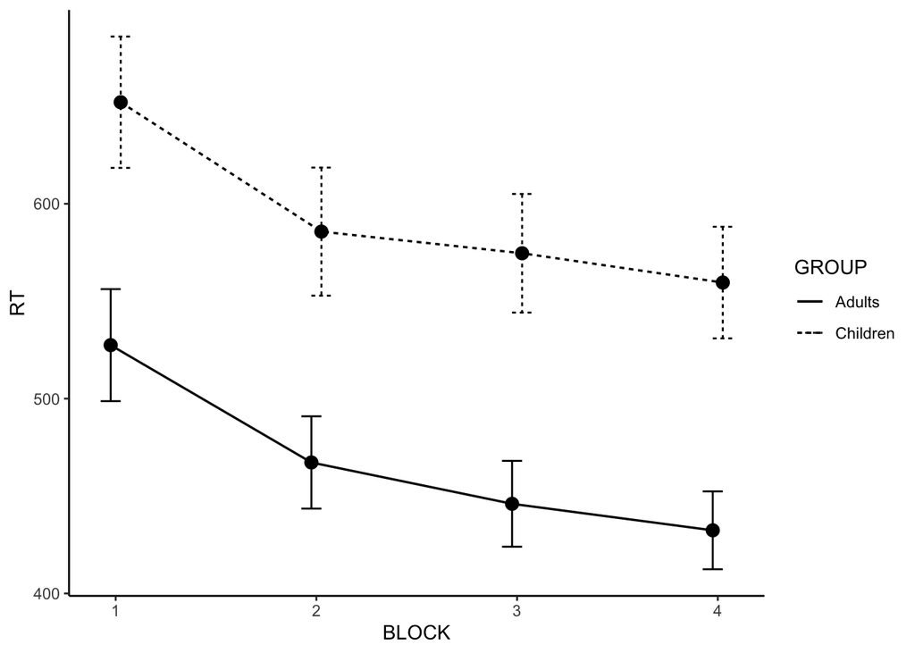

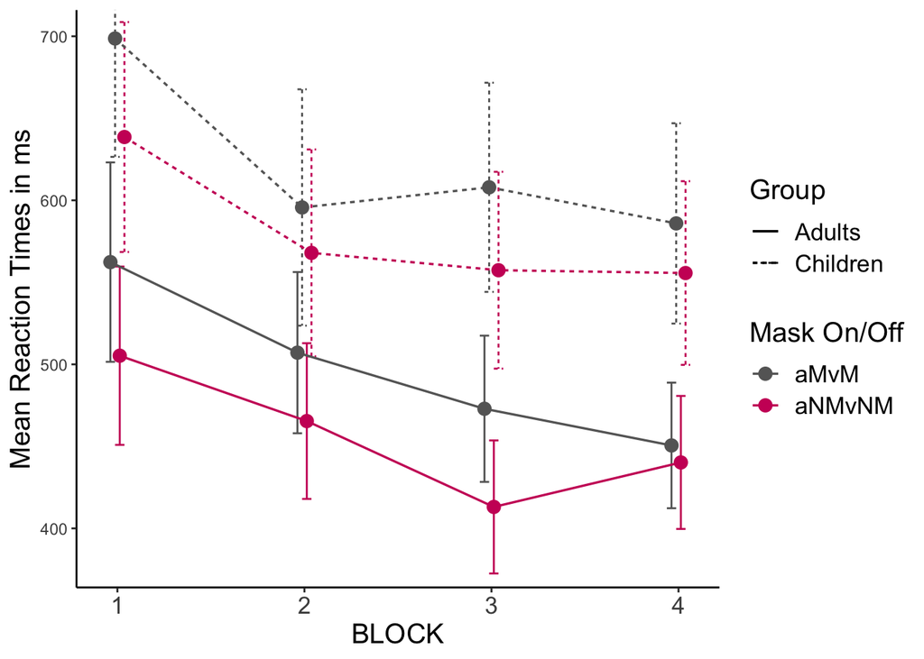